# 0. Abstract

## 0. Abstract

This report shows the development of a model to predict the type of motion performed by a weightlifter from measurements made by an accelerometer.

## 1. Background

Six participants wearing accelerometers were asked to lift a 1.25kg dumbell in five different types of motions or classes - one class being the motion corresponding to the exact specification of the Unilateral Dumbell Biceps Curl and the others being incorrect. These classes were labelled and described as follows:

- exactly according to the specification (Class A),
- throwing the elbows to the front (Class B),
- lifting the dumbbell only halfway (Class C),
- lowering the dumbbell only halfway (Class D) and
- throwing the hips to the front (Class E).

Each participant repeated each class of motion 10 times.

The participants wore accelerometers on the belt, arm and forearm, and an accelerometer was also attached to the dumbell.

More information is available at:

http://groupware.les.inf.puc-rio.br/har#ixzz4Yel0g0qr

## 2. Outline of Method

There ise test and training data for this study data from this study.

The training data for this project is available here:

https://d396qusza40orc.cloudfront.net/predmachlearn/pml-training.csv

The test data is available here:

https://d396qusza40orc.cloudfront.net/predmachlearn/pml-testing.csv

The following process was used to the develop the model

1. Both sets of data were downloaded.
2. The dimensions and format of the test data was investigated.
3. The data was prepared by cleaning it and further dividing the training data into training and validation datasets.
4. Given the type of output variable, consideration was given to what might be suitable predictors and all other columns of data were discarded from both the training and test datasets.
5. An initial model was considered and tried.
6. Other models were chosen and tested until a suitable model was found.

## 3. Running of the Process

## 3.1 Acquisition of Data

```r
wtrain<-"https://d396qusza40orc.cloudfront.net/predmachlearn/pml-training.csv"
wtest<-"https://d396qusza40orc.cloudfront.net/predmachlearn/pml-testing.csv"

download.file(wtrain,"weight_training")
download.file(wtest,"weight_testing")
barbell.train<-read.csv("weight_training")
barbell.test<-read.csv("weight_testing")
```

# 3.2 Dimension and Format of the Data

Using the commands dim and str on the training data as below

```
## [1] 19622   160
```

```
## 'data.frame':    19622 obs. of  160 variables:
##  $ X                       : int  1 2 3 4 5 6 7 8 9 10 ...
##  $ user_name               : Factor w/ 6 levels "adelmo","carlitos",..: 2 2 2 2 2 2 2 2 2 2 ...
##  $ raw_timestamp_part_1    : int  1323084231 1323084231 1323084231 1323084232 1323084232 1323084232 1323084232 1323084232 1323084232 1323084232 ...
##  $ raw_timestamp_part_2    : int  788290 808298 820366 120339 196328 304277 368296 440390 484323 484434 ...
##  $ cvtd_timestamp          : Factor w/ 20 levels "02/12/2011 13:32",..: 9 9 9 9 9 9 9 9 9 9 ...
##  $ new_window              : Factor w/ 2 levels "no","yes": 1 1 1 1 1 1 1 1 1 1 ...
##  $ num_window              : int  11 11 11 12 12 12 12 12 12 12 ...
##  $ roll_belt               : num  1.41 1.41 1.42 1.48 1.48 1.45 1.42 1.42 1.43 1.45 ...
##  $ pitch_belt              : num  8.07 8.07 8.07 8.05 8.07 8.06 8.09 8.13 8.16 8.17 ...
##  $ yaw_belt                : num  -94.4 -94.4 -94.4 -94.4 -94.4 -94.4 -94.4 -94.4 -94.4 -94.4 ...
##  $ total_accel_belt        : int  3 3 3 3 3 3 3 3 3 3 ...
##  $ kurtosis_roll_belt      : Factor w/ 397 levels "","0.000673",..: 1 1 1 1 1 1 1 1 1 1 ...
##  $ kurtosis_picth_belt     : Factor w/ 317 levels "","0.006078",..: 1 1 1 1 1 1 1 1 1 1 ...
##  $ kurtosis_yaw_belt       : Factor w/ 2 levels "","#DIV/0!": 1 1 1 1 1 1 1 1 1 1 ...
```

[output cut: 86 more lines]

showed that:

The variable classe is the variable to be predicted and is a classification variable with the values A,B,C,D and E.

## 3.3.2 Choosing Predictors

The result of the str(barbell_train) shown above indicates that the dataset has some columns that may have no effect on the class of movement. These columns have the names: X, user_name, raw_timestamp_part_1, raw_timestamp_part_2, cvtd_timestamp, new_window, and num_window.

To decide whether use these variables as predictors the following pairs plot was peformed as per the code below:

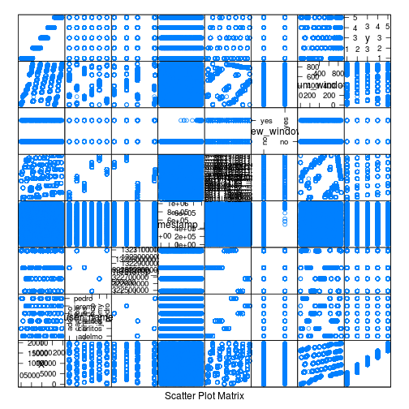

```r
featurePlot(x=barbell_train[,c("X","user_name", "raw_timestamp_part_1",
"raw_timestamp_part_2", "cvtd_timestamp", "new_window", "num_window")],
 y=as.numeric(barbell_train$classe), plot="pairs")
```

```r
barbell_train<-barbell_train[,8:ncol(barbell_train)]
```

## 3.3.3 Data for Validating Models

To validate each model the training dataset was split into a smaller training dataset and a validation dataset using createDataPartition

```r
set.seed(1234)
bartrain<-createDataPartition(barbell_train$classe,p=0.75,list=FALSE)
barbell_training<-barbell_train[bartrain,]
barbell_validation<-barbell_train[-bartrain,]
```

## 4. Selection and Testing of Models

## 4.1 Testing and Validation Procedure

To test each model cross-validation was used. To avoid sampling with replacement and to help performance, the cross-validation involved splitting the training data into folds. Too few folds could result in a model with bias whereas too many folds would increase the variance of the results. Therefore the training data was split into 10 folds and the model being tested on each of these using the R command train.

Once a fitted model was derived a prediction was made using the model on covariates from the validation dataset. These were compared with the classe variable in the validation dataset.

The variable to be predicted, classe is a classification variable so using linear regression will not be suitable. Even converting classe to a numberic value will not be useful for using liner regression, including generalised linear models, as assigning a numeric value to classe and trying to fit a linear model to derive it would imply that there are degrees of correctness in the method of lifting a dumbell.

The models to use in this situation are those used for classification. The simplest of these is using a classification tree. Using the R function train this can be achieved by using method rpart. The code and result are:

```r
# Set up parameters for cross-validation
trCont<-trainControl(method="cv",number=10)
set.seed(1234)
modFitTreeBar<-train(classe~., data=barbell_training, method="rpart",trControl=trCont)
print(modFitTreeBar)
```

```
## CART
##
## 14718 samples
##    52 predictors
##     5 classes: 'A', 'B', 'C', 'D', 'E'
##
## No pre-processing
## Resampling: Cross-Validated (10 fold)
## Summary of sample sizes: 13245, 13246, 13247, 13245, 13246, 13247, ...
## Resampling results across tuning parameters:
##
##   cp          Accuracy   Kappa
##   0.03446312  0.5139350  0.37599361
##   0.05987531  0.4026919  0.18679064
##   0.11535175  0.3228595  0.05880521
##
## Accuracy was used to select the optimal model using  the largest value.
## The final value used for the model was cp = 0.03446312.
```

An accuracy of about 51% is better than guessing but will give the wrong result in almost half the cases.

Random forest models allow allow for many trees to be developed and tested, often resulting in high accuracy. Therefore a random forest model was applied.

The code for training data using a random forest model is

```r
fitModRfBar<-train(x=barbell_training[,-ncol(barbell_training)], y=barbell_training$classe, data=barbell_training,
method="rf", method="rf",trControl=trCont)
```

```
## Error in train.default(x = barbell_training[, -ncol(barbell_training)], : formal argument "method" matched by multiple actual arguments
```

The accuracy is:

```r
 print(fitModRfBar)
```

[output not shown]

```r
predClassRF<-predict(fitModRfBar, newdata=barbell_validation)
table(predClassRF,barbell_validation$classe)
```

```
##
## predClassRF    A    B    C    D    E
##           A 1395    8    0    0    0
##           B    0  938    8    1    0
##           C    0    3  845    8    0
##           D    0    0    2  794    1
##           E    0    0    0    1  900
```

```r
(1-(sum(diag(table(predClassRF,barbell_validation$classe))[1:5])/length(predClassRF)))*100
```

```
## [1] 0.6525285
```

The code for doing this was:

```r
set.seed(1234)
 fitModGbmBar<-train(x=barbell_training[,-ncol(barbell_training)],
y=barbell_training$classe, meihod="gbm", trControl=trCont, verbose=FALSE)
```

The accuracy can be found in the following summary

```r
print(fitModGbmBar)
```

[output not shown]

When the model was applied to the validation data and the result compared to the variable classe in the validation data the result was as follows:

```r
predClassGBM<-predict(fitModGbmBar, barbell_validation)
table(predClassGBM,barbell_validation$classe)
```

```
##
## predClassGBM    A    B    C    D    E
##            A 1395    8    0    0    0
##            B    0  938    8    1    0
##            C    0    3  845    8    0
##            D    0    0    2  794    1
##            E    0    0    0    1  900
```

```r
(1-(sum(diag(table(predClassGBM,barbell_validation$classe))[1:5])/length(predClassGBM)))*100
```

```
## [1] 0.6525285
```